# ImageCLEF Medical Caption Task 2019

The [Image CLEF 2019 Concept Detection Task](https://www.imageclef.org/2019/medical/caption/) is a large-scale multi-label classification task aiming to identify medical terms (concepts) in radiology images. We will implement a system to classify a medical image based on several abnormalities represented by [Unified Medical Language System (UMLS)](https://www.nlm.nih.gov/research/umls/index.html) concept IDs.

> Vasileios Galanos  
> Msc in Data Science (Part-Time)  
> 1/2020

## Getting the Data

First, we download the data from Google Drive using the gdown utility.

```python
import gdown
import time
import zipfile

start = time.time()

# download training and val dataset
url = 'https://drive.google.com/uc?id=1UOccw0VNCiRTwaQSEJMhiYWXhizvKptX'
train_val = 'ImageCLEF2019.zip'
gdown.download(url, train_val, quiet=False)

# download test dataset
url = 'https://drive.google.com/uc?id=1diO2apPPFJeTH8CGcd3S55OUNTXtJVu2'
test = 'test_ImageCLEF2019.zip'
gdown.download(url, test, quiet=False)

end = time.time()
m, s = divmod(end - start, 60)
print('Downloading time: %.0f minutes' % m,'and %.0f seconds' % s)
```

```
Downloading...
From: https://drive.google.com/uc?id=1UOccw0VNCiRTwaQSEJMhiYWXhizvKptX
To: C:\Users\Owner\Desktop\Msc Data Science\Practical Data Science\Assigment 4\imageclef\ImageCLEF2019.zip
2.25GB [07:42, 4.86MB/s]
Downloading...
From: https://drive.google.com/uc?id=1diO2apPPFJeTH8CGcd3S55OUNTXtJVu2
To: C:\Users\Owner\Desktop\Msc Data Science\Practical Data Science\Assigment 4\imageclef\test_ImageCLEF2019.zip
708MB [02:24, 4.89MB/s]
```

```
Downloading time: 10 minutes and 10 seconds
```

We define the function `unzip` that we will use to unzip files in our dataset

```python
import os
import shutil

def unzip(filename, destination):
    with zipfile.ZipFile(filename,"r") as zip_ref:
        zip_ref.extractall(destination)

output = 'dataset'
```

Then, we extract all files to the proper locations

```python
start = time.time()

# delete folder if exists
if os.path.exists(output) and os.path.isdir(output):
    shutil.rmtree(output)

# unzip training and validation dataset
unzip(train_val, output)

# unzip test dataset
unzip(test, output)

# unzip training-set in subfolder
unzip(os.path.join(output, 'training-set.zip'), output)

# unzip validation-set in subfolder
unzip(os.path.join(output, 'validation-set.zip'), output)

# unzip test-set in subfolder
unzip(test, os.path.join(output, 'test-set'))

#remove zip files
os.remove(os.path.join(output, 'training-set.zip'))
os.remove(os.path.join(output, 'validation-set.zip'))

end = time.time()
m, s = divmod(end - start, 60)
print('Processing time: %.0f minutes' % m,'and %.0f seconds' % s)
```

```
Processing time: 4 minutes and 32 seconds
```

## Data Exploration/Preprocessing

As we see below, using the function `list_files` , the **training**, **validation** and **test** set are in their own directories.

```python
# adapted from https://stackoverflow.com/a/9728478
def list_files(start_path, num_files):
    for root, dirs, files in os.walk(start_path):
        level = root.replace(start_path, '').count(os.sep)
        indent = ' ' * 4 * (level)
        print(indent + os.path.basename(root) + '/', end='')
        if len(files) != 0:
            print()
        sub_indent = ' ' * 4 * (level + 1)
        print(sub_indent, end='')
        for i, f in enumerate(files):
            print(f, end=' ')
            if i == num_files - 1:
                break
        print()
```

```python
list_files(output, 3)
```

```
dataset/
    string_concepts.csv train_concepts.csv val_concepts.csv
    test-set/
        Last/
            ROCO_CLEF_TEST_00001.jpg ROCO_CLEF_TEST_00002.jpg ROCO_CLEF_TEST_00003.jpg
    training-set/
        ROCO_CLEF_00000.jpg ROCO_CLEF_00001.jpg ROCO_CLEF_00003.jpg
    validation-set/
        ROCO_CLEF_00002.jpg ROCO_CLEF_00006.jpg ROCO_CLEF_00010.jpg
```

Below, we calculate exactly how many images we have in each dataset.

```python
import pandas as pd

train_dir = os.path.join(output, 'training-set')
val_dir = os.path.join(output, 'validation-set')
test_dir = os.path.join(output, os.path.join('test-set','Last'))

num_train = len(os.listdir(train_dir))
num_val = len(os.listdir(val_dir))
num_test = len(os.listdir(test_dir))

print('total training images:', num_train)

print('total validation images:', num_val)

print('total test images:', num_test)
```

```
total training images: 56629
total validation images: 14157
total test images: 10000
```

and we visualize the distribution of our data using `seaborn`

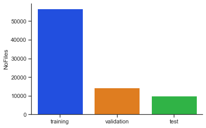

```python
import seaborn as sns
import matplotlib.pyplot as plt

total_files = pd.DataFrame({'NoFiles': [num_train,num_val,num_test]},index = ['training','validation','test'])

sns.set(style="ticks")

ax = sns.barplot(x=total_files.index,y='NoFiles',palette="bright",data=total_files)

ax.spines['right'].set_visible(False)
ax.spines['top'].set_visible(False)

plt.show()
```

We import the concepts tags for the training set to a dataframe. The column `tags` contains a list with the concept ids for each row/image

```python
df = pd.read_csv(os.path.join(output, 'train_concepts.csv'))
df['tags']=df['tags'].apply(lambda x:x.split(";"))
df['image']=df['image']+'.jpg'

df_val = pd.read_csv(os.path.join(output, 'val_concepts.csv'))
df_val['tags']=df_val['tags'].apply(lambda x:x.split(";"))
df_val['image']=df_val['image']+'.jpg'
```

- We also import the file that contains all the concept ids (`tag_id`) with their corresponding descriptions (`tag_name`)
- We also print out the number of unique concepts

```python
cn = pd.read_csv(os.path.join(output, 'string_concepts.csv'),sep='\t',header=None,names=['tag_id', 'tag_name'])
print('Total number of unique tags:', len(cn.tag_id.unique()))

concepts_dict = dict(zip(cn.tag_id, cn.tag_name))
```

```
Total number of unique tags: 5528
```

Obviously, we cannot expect to load all of our images to memory in order to train our models due to the large storage space that it would need.

- Thus, we use an [ImageDataGenerator](https://keras.io/preprocessing/image/), offerred by keras, in order to read the images in batches.
- This will create a Python generator that, when we call it, will return the next batch and also scale the pixel value from 0 to 1.
- We use this generator with `flow_from_dataframe` method in order to read the images from the directory according to the values of the training set dataframe `df`
- Each image will be resized to `IMG_HEIGHT` * `IMAGE_WIDTH` and the contents of the dataframe will be shuffled

```python
import tensorflow as tf

from tensorflow.keras.preprocessing.image import ImageDataGenerator

import numpy as np

batch_size = 13
epochs = 5
IMG_HEIGHT = 128
IMG_WIDTH = 128
seed = 94
concepts_list = cn.tag_id.values.tolist() # list that contains the unique tag_ids

train_image_generator = ImageDataGenerator(rescale=1./255) # Generator for our training data
train_data_gen = train_image_generator.flow_from_dataframe(
    dataframe=df,
    directory=train_dir,
    x_col="image",
    y_col="tags",
    class_mode="categorical",
    color_mode="rgb",
    classes=concepts_list,
    batch_size=batch_size,
    shuffle=True,
    target_size=(IMG_HEIGHT, IMG_WIDTH),
    validate_filenames = True,
    seed=seed
)
```

```
Found 56629 validated image filenames belonging to 5528 classes.
```

Our generator produces the next batch of image arrays along with their labels, using a multi-hot encoding that we provided with our `concept_list`. In order to transform encoded data, back to their original form (string labels), we create a dictionary as follows

```python
labels = (train_data_gen.class_indices)
labels = dict((v,k) for k,v in labels.items())
```

We repeat the same process, so that we make a generator for the validation set as well.

```python
val_image_generator = ImageDataGenerator(rescale=1./255) # Generator for our validation data
val_data_gen = val_image_generator.flow_from_dataframe(
    dataframe=df_val,
    directory=val_dir,
    x_col="image",
    y_col="tags",
    class_mode="categorical",
    color_mode="rgb",
    classes=concepts_list,
    batch_size=batch_size,
    shuffle=True,
    target_size=(IMG_HEIGHT, IMG_WIDTH),
    validate_filenames = True,
    seed=seed
)
```

```
Found 14157 validated image filenames belonging to 5528 classes.
```

```python
labels_val = (val_data_gen.class_indices)
labels_val = dict((v,k) for k,v in labels_val.items())
```

Now, we will create

- a function that receives a batch of images, with their label arrays and produce a figure with the images and their concept ids
- a function that receives batch of images, their label arrays and a number that will specify which of the images will be plotted along with its concept ids and their descriptions

```python
def plot_5_images(images_arr, labels_arr):
    fig = plt.figure(figsize=(20,20))
    for i in range(5):
        ax = plt.subplot(1,5,i+1)
        plt.imshow(images_arr[i])
        plt.title('')
        plt.xticks([])
        plt.yticks([])
        plt.grid(False)
        plt.xlabel("\n".join(
            [concepts_dict[labels[ind]] for ind,value in enumerate(labels_arr[i])
             if value==1])
                   ,horizontalalignment='center'
                   , fontsize=15
                   ,wrap=True
                  )
        plt.tight_layout()
```

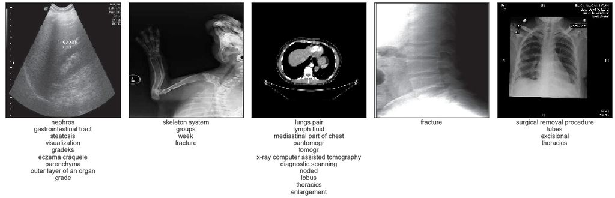

```python
sample_training_images, sample_training_labels = next(train_data_gen)
plot_5_images(sample_training_images, sample_training_labels)
```

```python
def plot_image(images_arr, labels_arr, pic):
    fig, ax = plt.subplots(1,1, figsize=(7,7))
    plt.imshow(images_arr[pic])
    plt.title('')
    plt.xticks([])
    plt.yticks([])
    plt.grid(False)
    plt.xlabel("\n".join(
         [labels[ind]+': '+concepts_dict[labels[ind]] for ind,value in enumerate(labels_arr[pic])
         if value==1])
               ,horizontalalignment='center'
               , fontsize=15
               ,wrap=True
             )
    #plt.tight_layout()
```

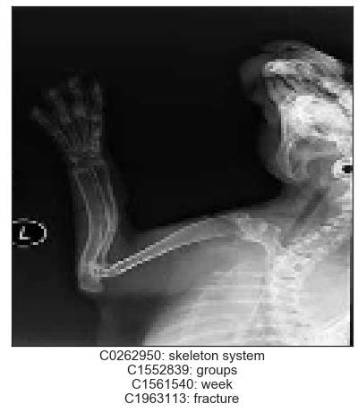

```python
plot_image(sample_training_images, sample_training_labels, 1)
```

In order to find the most common tags,

- we use a `CountVectorizer` fitted in all the concepts from the file `string_concepts.csv`
- we then create a list with all the available tags from the training and validation set
- we transform this list using the vectorizer, in order to produce a bag of words. Now for each tag, we have the number of times that it appeared in all the datasets.
- We then transform the frequencies to probabilities using the total number of tags that appeared in both datasets.

```python
from sklearn.feature_extraction.text import CountVectorizer

vectorizer = CountVectorizer(lowercase=False)

# fit vectorizer to unique terms from string concepts
vectorizer.fit(cn.tag_id.values.tolist())

# flatten the list of lists
train_captions_list = [labels[item] for sublist in train_data_gen.classes for item in sublist]
val_captions_list = [labels_val[item] for sublist in val_data_gen.classes for item in sublist]
captions_list = train_captions_list + val_captions_list

# keep total number of captions in training set
total_captions = len(captions_list) #len(set(train_captions_list))

# transform the input for vectorizer
joined_captions_list = [','.join(captions_list)]

# apply the vectorizer
captions_count = vectorizer.transform(joined_captions_list).todense()

# create dataframe using the vectorizer's vocabulary
captions_freqs = pd.DataFrame.from_dict(vectorizer.vocabulary_,orient='index',columns=['ind'])

# create column with the frequencies for each caption in the training set
captions_freqs['freq'] = captions_freqs['ind'].apply(lambda x: captions_count.item(x))

# create column with probabilities using unique training captions
captions_freqs['prob'] = captions_freqs['freq']/total_captions

captions_freqs = captions_freqs.sort_values(by=['freq'],ascending=False)
print('Total number of tags',total_captions)
print('Most frequent tags :\n\n', captions_freqs.iloc[:10,2])
```

```
Total number of tags 432753
Most frequent tags :

 C0441633    0.019468
C0043299    0.018269
C1962945    0.018260
C0040395    0.017786
C0034579    0.017479
C0817096    0.017262
C0040405    0.016554
C1548003    0.014854
C0221198    0.013121
C0772294    0.013118
Name: prob, dtype: float64
```

We also find the average number of concepts per image in both datasets

```python
df['count_tags']= df.tags.apply(lambda x: len(x)  )
df_val['count_tags']= df_val.tags.apply(lambda x: len(x)  )
print('Average number of concepts per image: ',int(round(np.mean([df.count_tags.mean(),df_val.count_tags.mean()]))) )
```

```
Average number of concepts per image:  6
```

and plot the histogram with the distribution of number of concepts per image

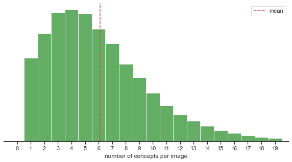

```python
fig, ax = plt.subplots(1,1, figsize=(10,5))
ticks = np.arange(20)
sns.distplot(pd.concat([df,df_val], ignore_index=True).count_tags
            ,kde=False
            ,color = 'forestgreen'
            ,bins=np.arange(0,21)-0.5
            ,hist_kws=dict(alpha=0.7)
            ,ax = ax)
plt.xlim([-1, 20])
ax.spines['right'].set_visible(False)
ax.spines['left'].set_visible(False)
ax.spines['top'].set_visible(False)
ax.set_yticks([])

ax.set(xlabel='number of concepts per image')

ax.axvline(df.count_tags.mean(), color='r', linestyle='--')
plt.legend(['mean'])
plt.xticks(range(20));
```

## Baseline Model

We create a baseline classifier in order to measure our efforts.

- This classifier, receives a list with the image filenames , and a seed for the random generator.
- It then samples from all the available tags, using their corresponding probabilities tha we found earlier
- It returns a dictionary with the filename and the six sampled tag ids.
- We choose six, because it is the average number of tags per image.
- Lastly, we create two files with the image names and their corresponding labels. `val_baseline.csv` stores the predicted labels using the baseline classifier on the validation set, while `val_ground_truth.csv` is the ground truth file with the correct concept labels for each image in the validation set.

```python
import csv

def baseline_classifier(images, input_seed):
    np.random.seed(seed)
    d = dict()
    for image in images:
        sampled_captions = list(np.random.choice(captions_freqs.index.values, 6, p=captions_freqs.prob.values,replace =False))
        d.update({image:sampled_captions})
    return d

baseline_val_dict = baseline_classifier(df_val.image.tolist(),1)
df_val['baseline_tags'] = df_val['image'].map(baseline_val_dict)

df_val['baseline_tags_formated'] = df_val['baseline_tags'].apply(lambda x: ';'.join(map(str,x)))
df_val['tags_formated'] = df_val['tags'].apply(lambda x: ';'.join(map(str,x)))

df_val.to_csv(r'val_baseline.csv'
              ,index=False
              ,header=False
              ,quoting=csv.QUOTE_NONE
              ,escapechar = ''
              ,sep='\t'
             ,columns=['image','baseline_tags_formated'])

df_val.to_csv(r'val_ground_truth.csv'
              ,index=False
              ,header=False
              ,quoting=csv.QUOTE_NONE
              ,escapechar = ''
              ,sep='\t'
             ,columns=['image','tags_formated'])

df_val.drop(['baseline_tags_formated', 'tags_formated'], axis=1, inplace=True)
```

We run the `evaluate-f1.py`, as instructed in the [competition web page](https://www.imageclef.org/2019/medical/caption/).

- We got a 2% average F1 score over all our validation images.

```python
%run -i "ImageCLEF-ConceptDetection-Evaluation/evaluate-f1.py" "val_baseline.csv" "val_ground_truth.csv"
```

```
Input parameters
Candidate file is "val_baseline.csv"
Ground Truth file is "val_ground_truth.csv"
Processing concept sets...
1000 / 14157  concept sets processed...
2000 / 14157  concept sets processed...
3000 / 14157  concept sets processed...
4000 / 14157  concept sets processed...
5000 / 14157  concept sets processed...
6000 / 14157  concept sets processed...
7000 / 14157  concept sets processed...
8000 / 14157  concept sets processed...
9000 / 14157  concept sets processed...
10000 / 14157  concept sets processed...
11000 / 14157  concept sets processed...
```

[output cut: 45 more lines]

## Neural Network

Before we train any models and compare their [F1 scores](https://scikit-learn.org/stable/modules/generated/sklearn.metrics.f1_score.html), we need to define a new `ImageGenerator()`.

- This generator will fetch images from the `validation-set` as before, but this time it will not shuffle them. We specify that utility with `shuffle=False` in order to ensure that our images are aligned with the `filenames`

```python
val_test_image_generator = ImageDataGenerator(rescale=1./255) # Generator for our training data
val_test_gen = val_test_image_generator.flow_from_dataframe(
    dataframe=df_val,
    directory=val_dir,
    x_col="image",
    y_col="tags",
    class_mode="categorical",
    color_mode="rgb",
    classes=concepts_list,
    batch_size=batch_size,
    shuffle=False,
    target_size=(IMG_HEIGHT, IMG_WIDTH),
    validate_filenames = True,
    seed=seed
)
```

```
Found 14157 validated image filenames belonging to 5528 classes.
```

The method that we will use in order to predict the concepts for the images is [Transfer Learning](https://en.wikipedia.org/wiki/Transfer_learning).

- We will use pre-trained deep learning models from [Keras Applications](https://keras.io/applications/), in order to extract the features from the images.
- We will add the predictions layers for our multi-label classification problem accordingly, and train the models in our datasets only on those layers, because we don't want to change the way that these powerfull models extract features.
- The first deep learning model is `MobileNet V2`, that we will compile with a `binary crossentropy` loss function and an `Adam` optimizer.
- The last prediction layer will have as many outputs as our labels (5528) and a `sigmoid` activation function. We use this type of activation function (and not a `softmax`) because we have a multi-label classification problem where all our outputs are independent of each other.
- We choose a `batch size = 13` and resize our images to `128*128` in order to avoid to run out of RAM memory.

```python
from tensorflow.keras import datasets, layers, models, optimizers

IMG_SHAPE = (IMG_WIDTH, IMG_HEIGHT, 3)

# Create the base model from the pre-trained model MobileNet V2
base_model = tf.keras.applications.MobileNetV2(input_shape=IMG_SHAPE,
                                               include_top=False,
                                               weights='imagenet')
base_model.trainable = False
base_model.summary()
```

```
Model: "mobilenetv2_1.00_128"
__________________________________________________________________________________________________
Layer (type)                    Output Shape         Param #     Connected to
==================================================================================================
input_2 (InputLayer)            [(None, 128, 128, 3) 0
__________________________________________________________________________________________________
Conv1_pad (ZeroPadding2D)       (None, 129, 129, 3)  0           input_2[0][0]
__________________________________________________________________________________________________
Conv1 (Conv2D)                  (None, 64, 64, 32)   864         Conv1_pad[0][0]
__________________________________________________________________________________________________
bn_Conv1 (BatchNormalization)   (None, 64, 64, 32)   128         Conv1[0][0]
__________________________________________________________________________________________________
Conv1_relu (ReLU)               (None, 64, 64, 32)   0           bn_Conv1[0][0]
__________________________________________________________________________________________________
expanded_conv_depthwise (Depthw (None, 64, 64, 32)   288         Conv1_relu[0][0]
__________________________________________________________________________________________________
expanded_conv_depthwise_BN (Bat (None, 64, 64, 32)   128         expanded_conv_depthwise[0][0]
__________________________________________________________________________________________________
expanded_conv_depthwise_relu (R (None, 64, 64, 32)   0           expanded_conv_depthwise_BN[0][0]
__________________________________________________________________________________________________
expanded_conv_project (Conv2D)  (None, 64, 64, 16)   512         expanded_conv_depthwise_relu[0][0
__________________________________________________________________________________________________
expanded_conv_project_BN (Batch (None, 64, 64, 16)   64          expanded_conv_project[0][0]
__________________________________________________________________________________________________
block_1_expand (Conv2D)         (None, 64, 64, 96)   1536        expanded_conv_project_BN[0][0]
__________________________________________________________________________________________________
block_1_expand_BN (BatchNormali (None, 64, 64, 96)   384         block_1_expand[0][0]
__________________________________________________________________________________________________
block_1_expand_relu (ReLU)      (None, 64, 64, 96)   0           block_1_expand_BN[0][0]
__________________________________________________________________________________________________
block_1_pad (ZeroPadding2D)     (None, 65, 65, 96)   0           block_1_expand_relu[0][0]
__________________________________________________________________________________________________
block_1_depthwise (DepthwiseCon (None, 32, 32, 96)   864         block_1_pad[0][0]
__________________________________________________________________________________________________
block_1_depthwise_BN (BatchNorm (None, 32, 32, 96)   384         block_1_depthwise[0][0]
__________________________________________________________________________________________________
block_1_depthwise_relu (ReLU)   (None, 32, 32, 96)   0           block_1_depthwise_BN[0][0]
__________________________________________________________________________________________________
block_1_project (Conv2D)        (None, 32, 32, 24)   2304        block_1_depthwise_relu[0][0]
__________________________________________________________________________________________________
```

[output cut: 273 more lines]

```
__________________________________________________________________________________________________
block_16_project (Conv2D)       (None, 4, 4, 320)    307200      block_16_depthwise_relu[0][0]
__________________________________________________________________________________________________
block_16_project_BN (BatchNorma (None, 4, 4, 320)    1280        block_16_project[0][0]
__________________________________________________________________________________________________
Conv_1 (Conv2D)                 (None, 4, 4, 1280)   409600      block_16_project_BN[0][0]
__________________________________________________________________________________________________
Conv_1_bn (BatchNormalization)  (None, 4, 4, 1280)   5120        Conv_1[0][0]
__________________________________________________________________________________________________
out_relu (ReLU)                 (None, 4, 4, 1280)   0           Conv_1_bn[0][0]
==================================================================================================
Total params: 2,257,984
Trainable params: 0
Non-trainable params: 2,257,984
__________________________________________________________________________________________________
```

```python
sample_training_images, _ = next(train_data_gen)

feature_batch = base_model(sample_training_images)
print(feature_batch.shape)

global_average_layer = tf.keras.layers.GlobalAveragePooling2D()
feature_batch_average = global_average_layer(feature_batch)
print(feature_batch_average.shape)

prediction_layer = layers.Dense(len(concepts_list), activation='sigmoid')
prediction_batch = prediction_layer(feature_batch_average)
print(prediction_batch.shape)

model = tf.keras.Sequential([
  base_model,
  global_average_layer,
  prediction_layer
])

model.summary()
```

```
(13, 4, 4, 1280)
(13, 1280)
(13, 5528)
Model: "sequential"
_________________________________________________________________
Layer (type)                 Output Shape              Param #
=================================================================
mobilenetv2_1.00_128 (Model) (None, 4, 4, 1280)        2257984
_________________________________________________________________
global_average_pooling2d_4 ( (None, 1280)              0
_________________________________________________________________
dense_1 (Dense)              (None, 5528)              7081368
=================================================================
Total params: 9,339,352
Trainable params: 7,081,368
Non-trainable params: 2,257,984
_________________________________________________________________
```

```python
base_learning_rate = 0.01
model.compile(optimizer=optimizers.Adam(),
              loss='binary_crossentropy',
              metrics=['accuracy'])
```

We train for 5 epochs using our training and validation datasets and save it.

```python
model.fit(
    train_data_gen,
    steps_per_epoch=num_train // batch_size,
    epochs=epochs,
    validation_data=val_data_gen,
    validation_steps=num_val // batch_size
    , verbose=1
)

model.save('trained_models/mobile_imageclef.h5')
```

[output not shown]

```
<tensorflow.python.keras.callbacks.History at 0x26233e6edc8>
```

```python
from tensorflow.keras.models import load_model

model_mobile = load_model('trained_models/mobile_imageclef.h5')
```

Then, we make the predictions using this model, one batch at a time .

```python
val_test_gen.reset()
pred=model_mobile.predict_generator(val_test_gen,
steps=num_val // batch_size,
verbose=1)
```

As the [paper](http://nlp.cs.aueb.gr/pubs/paper_136.pdf) from the NLP group suggested we choose `0.16` as our threshold for the prediction of a label

```python
pred_bool = (pred >0.16)
predictions=[]

for row in pred_bool:
    l=[]
    for index,cls in enumerate(row):
        if cls:
            l.append(labels_val[index])
    predictions.append(";".join(l))
filenames=val_test_gen.filenames
results=pd.DataFrame({"Filename":filenames,
                      "Predictions":predictions})
results.head()
```

|  | Filename | Predictions |
| --- | --- | --- |
| 0 | ROCO_CLEF_64017.jpg | C0006141;C0015392;C0175676;C0203463;C0262950;C... |
| 1 | ROCO_CLEF_39073.jpg | C0037949;C0043299;C0184913;C0221198;C0262950;C... |
| 2 | ROCO_CLEF_18028.jpg | C0018670;C0221198;C0224155;C0441633;C0772294;C... |
| 3 | ROCO_CLEF_02052.jpg | C0043299;C0087111;C0262950;C1306232;C1548003;C... |
| 4 | ROCO_CLEF_67927.jpg | C0000726;C0013687;C0017181;C0043299;C0332448;C... |

Now, we save the results in a `csv` file with the appropriate format in order to evaluate the results

```python
import csv

results.to_csv(r'val_mobile_v1.csv'
              ,index=False
              ,header=False
              ,quoting=csv.QUOTE_NONE
              ,escapechar = ''
              ,sep='\t'
             ,columns=['Filename','Predictions'])
```

As we can see below, we achieved a `12%` F1 score averaged for all validation images, using the `MobileNet V2`, which is surprisingly good compared to the `2%` of our baseline.

```python
%run -i "ImageCLEF-ConceptDetection-Evaluation/evaluate-f1.py" "val_mobile_v1.csv" "val_ground_truth.csv"
```

```
Input parameters
Candidate file is "val_mobile_v1.csv"
Ground Truth file is "val_ground_truth.csv"
Processing concept sets...
1000 / 14157  concept sets processed...
2000 / 14157  concept sets processed...
3000 / 14157  concept sets processed...
4000 / 14157  concept sets processed...
5000 / 14157  concept sets processed...
6000 / 14157  concept sets processed...
7000 / 14157  concept sets processed...
8000 / 14157  concept sets processed...
9000 / 14157  concept sets processed...
10000 / 14157  concept sets processed...
11000 / 14157  concept sets processed...
```

[output cut: 45 more lines]

Next, we will try a different architecture for the feature extraction, using a `DenseNet-121` and adding the same layers as before.

```python
base_model = tf.keras.applications.densenet.DenseNet121(input_shape=IMG_SHAPE,
                                               include_top=False,
                                               weights='imagenet')
feature_batch = base_model(sample_training_images)

base_model.trainable = False

global_average_layer = tf.keras.layers.GlobalAveragePooling2D()
feature_batch_average = global_average_layer(feature_batch)

prediction_layer = layers.Dense(len(concepts_list), activation='sigmoid')
prediction_batch = prediction_layer(feature_batch_average)

model = tf.keras.Sequential([
  base_model,
  global_average_layer,
  prediction_layer
])

model.summary()
```

```
Model: "sequential_1"
_________________________________________________________________
Layer (type)                 Output Shape              Param #
=================================================================
densenet121 (Model)          (None, 4, 4, 1024)        7037504
_________________________________________________________________
global_average_pooling2d_5 ( (None, 1024)              0
_________________________________________________________________
dense_2 (Dense)              (None, 5528)              5666200
=================================================================
Total params: 12,703,704
Trainable params: 5,666,200
Non-trainable params: 7,037,504
_________________________________________________________________
```

```python
base_learning_rate = 0.0001
model.compile(optimizer=tf.keras.optimizers.RMSprop(lr=base_learning_rate),
              loss='binary_crossentropy',
              metrics=['accuracy'])

epochs = 10

history = model.fit(
    train_data_gen,
    steps_per_epoch=num_train // batch_size,
    epochs=epochs,
    validation_data=val_data_gen,
    validation_steps=num_val // batch_size
)
model.save('trained_models/densenet_imageclef.h5')
```

```
Train for 4356 steps, validate for 1089 steps
```

As we see below, the F1 score on the validation set improved to `~15%`, so that is a better model to use for our problem.

```python
model_dense = load_model('trained_models/densenet_imageclef.h5')

val_test_gen.reset()
pred=model_dense.predict_generator(val_test_gen,
steps=num_val // batch_size,
verbose=1)

pred_bool = (pred >0.16)
predictions=[]

for row in pred_bool:
    l=[]
    for index,cls in enumerate(row):
        if cls:
            l.append(labels_val[index])
    predictions.append(";".join(l))
filenames=val_test_gen.filenames
results=pd.DataFrame({"Filename":filenames,
                      "Predictions":predictions})


results.to_csv(r'val_densenet_10.csv'
              ,index=False
              ,header=False
              ,quoting=csv.QUOTE_NONE
              ,escapechar = ''
              ,sep='\t'
             ,columns=['Filename','Predictions'])

%run -i "ImageCLEF-ConceptDetection-Evaluation/evaluate-f1.py" "val_densenet_10.csv" "val_ground_truth.csv"
```

```
Input parameters
Candidate file is "val_densenet_10.csv"
Ground Truth file is "val_ground_truth.csv"
Processing concept sets...
1000 / 14157  concept sets processed...
2000 / 14157  concept sets processed...
3000 / 14157  concept sets processed...
4000 / 14157  concept sets processed...
5000 / 14157  concept sets processed...
6000 / 14157  concept sets processed...
7000 / 14157  concept sets processed...
8000 / 14157  concept sets processed...
9000 / 14157  concept sets processed...
10000 / 14157  concept sets processed...
11000 / 14157  concept sets processed...
```

[output cut: 45 more lines]

## Test set

Lastly, we will produce a file with our solutions on the test set

- We will create a dataframe with all the imagenames from the test-set
- Then, we will create an `ImageDataGenerator` that will fetch us batches of the test-set images
- We will use the `DenseNet` based model, for our predictions and store them in a `.csv` file along with the image names

```python
data = []
for file in os.listdir(test_dir):
    data.append( file)
df_test = pd.DataFrame(data, columns=['image'])
```

```python
test_image_generator = ImageDataGenerator(rescale=1./255) # Generator for our training data
test_gen = test_image_generator.flow_from_dataframe(
    dataframe=df_test,
    directory=test_dir,
    x_col="image",
    class_mode=None,
    color_mode="rgb",
    batch_size=10,
    shuffle=False,
    target_size=(IMG_HEIGHT, IMG_WIDTH),
    validate_filenames = True,
    seed=seed
)
```

```
Found 10000 validated image filenames.
```

```python
test_gen.reset()

pred=model_dense.predict_generator(test_gen,
steps=num_test // 10,
verbose=1)

pred_bool = (pred >0.16)
predictions=[]

for row in pred_bool:
    l=[]
    for index,cls in enumerate(row):
        if cls:
            l.append(labels_val[index])
    predictions.append(";".join(l))
filenames=test_gen.filenames
results=pd.DataFrame({"Filename":filenames,
                      "Predictions":predictions})
results['Filename'].replace('.jpg','',regex=True,inplace=True)

results.to_csv(r'test_results_VasileiosGalanos.csv'
              ,index=False
              ,header=False
              ,quoting=csv.QUOTE_NONE
              ,escapechar = ''
              ,sep='\t'
             ,columns=['Filename','Predictions'])
```

We can also plot some test images, along with the predicted caption labels

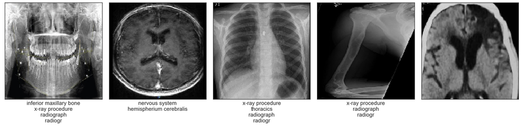

```python
test_sample = next(test_gen)

predictions = model_dense.predict(test_sample)
predictions[predictions > 0.16] = 1
predictions[predictions <= 0.16] = 0

plot_5_images(test_sample, predictions)
```